# Cardio Good Fitness Project

(Case Study)

### Description of Dataset:

Product - The model no. of the treadmill

Age - Age of the customer in no of years

Gender - Gender of the customer

Education - Education of the customer in no. of years

Marital Status - Marital status of the customer

Usage - Avg. # times the customer wants to use the treadmill every week

Fitness - Self rated fitness score of the customer (5 - very fit, 1 - very unfit)

Income - Income of the customer

Miles- Miles that a customer expects to run

# 1. Initial Analysis / Structure of the Data

### 1.a Import the Python Libraries

```python
import pandas as pd #pandas
import seaborn as sns   # seaborn
import matplotlib.pyplot as plt  # matplotlib.pyplot
sns.set(color_codes=True) # adds a nice background to the graphs
%matplotlib inline
import warnings #warnings
warnings.filterwarnings('ignore')
```

### 1.b Read the dataset - CardioGoodFitness.csv

```python
cardiodata = pd.read_csv('CardioGoodFitness.csv') #Read the datafile
```

### 1.c Check the number of records and columns

```python
cardiodata.shape #find the number of rows and columns
```

```
(180, 9)
```

Observation: The dataset has 180 rows and 9 columns

### 1.d Check the columns

```python
cardiodata.columns # List all the columns of the dataset
```

```
Index(['Product', 'Age', 'Gender', 'Education', 'MaritalStatus', 'Usage',
       'Fitness', 'Income', 'Miles'],
      dtype='object')
```

Observation: The names of the columns are consistent with the description of dataset

### 1.e Check the first few rows of dataset

```python
cardiodata.head() # Quick view of the first 5 rows
```

|  | Product | Age | Gender | Education | MaritalStatus | Usage | Fitness | Income | Miles |
| --- | --- | --- | --- | --- | --- | --- | --- | --- | --- |
| 0 | TM195 | 18 | Male | 14 | Single | 3 | 4 | 29562 | 112 |
| 1 | TM195 | 19 | Male | 15 | Single | 2 | 3 | 31836 | 75 |
| 2 | TM195 | 19 | Female | 14 | Partnered | 4 | 3 | 30699 | 66 |
| 3 | TM195 | 19 | Male | 12 | Single | 3 | 3 | 32973 | 85 |
| 4 | TM195 | 20 | Male | 13 | Partnered | 4 | 2 | 35247 | 47 |

Observation: Dataset looks clean and consistent with definitions of Data Dictionary

### 1.f Check for any null values

```python
cardiodata.isnull().sum() # Check for Null values and count their totals
```

```
Product          0
Age              0
Gender           0
Education        0
MaritalStatus    0
Usage            0
Fitness          0
Income           0
Miles            0
dtype: int64
```

Observation: There are no missing or null values in the dataset

### 1.g Check the data types of each column

```python
cardiodata.info() #structure of the data, explaining the columns and their data types
```

```
<class 'pandas.core.frame.DataFrame'>
RangeIndex: 180 entries, 0 to 179
Data columns (total 9 columns):
 #   Column         Non-Null Count  Dtype
---  ------         --------------  -----
 0   Product        180 non-null    object
 1   Age            180 non-null    int64
 2   Gender         180 non-null    object
 3   Education      180 non-null    int64
 4   MaritalStatus  180 non-null    object
 5   Usage          180 non-null    int64
 6   Fitness        180 non-null    int64
 7   Income         180 non-null    int64
 8   Miles          180 non-null    int64
dtypes: int64(6), object(3)
memory usage: 12.8+ KB
```

Observation: Product, Gender and Marital Status are Categorical fields, rest are quantitative fields

### 1.h Statistical Summary of the data

```python
cardiodata.describe(include='all') # Statistical Summary
```

|  | Product | Age | Gender | Education | MaritalStatus | Usage | Fitness | Income | Miles |
| --- | --- | --- | --- | --- | --- | --- | --- | --- | --- |
| count | 180 | 180.000000 | 180 | 180.000000 | 180 | 180.000000 | 180.000000 | 180.000000 | 180.000000 |
| unique | 3 | NaN | 2 | NaN | 2 | NaN | NaN | NaN | NaN |
| top | TM195 | NaN | Male | NaN | Partnered | NaN | NaN | NaN | NaN |
| freq | 80 | NaN | 104 | NaN | 107 | NaN | NaN | NaN | NaN |
| mean | NaN | 28.788889 | NaN | 15.572222 | NaN | 3.455556 | 3.311111 | 53719.577778 | 103.194444 |
| std | NaN | 6.943498 | NaN | 1.617055 | NaN | 1.084797 | 0.958869 | 16506.684226 | 51.863605 |
| min | NaN | 18.000000 | NaN | 12.000000 | NaN | 2.000000 | 1.000000 | 29562.000000 | 21.000000 |
| 25% | NaN | 24.000000 | NaN | 14.000000 | NaN | 3.000000 | 3.000000 | 44058.750000 | 66.000000 |
| 50% | NaN | 26.000000 | NaN | 16.000000 | NaN | 3.000000 | 3.000000 | 50596.500000 | 94.000000 |
| 75% | NaN | 33.000000 | NaN | 16.000000 | NaN | 4.000000 | 4.000000 | 58668.000000 | 114.750000 |
| max | NaN | 50.000000 | NaN | 21.000000 | NaN | 7.000000 | 5.000000 | 104581.000000 | 360.000000 |

Observation: This data is about usage of 3 models of Treadmills (TM195 is the top) , usage by both Male (104) and Female Customers, and 107 of them are partnered. The data appears to be evenly distributed, as mean values are closer to the 50% value for Age, Education, Fitness, Income. For Miles it is heavy right tail as mean is greater than 50% value

### 1.i Find the range of Age for the Customers

```python
cardiodata['Age'].unique() # find the range of the values for Age
```

```
array([18, 19, 20, 21, 22, 23, 24, 25, 26, 27, 28, 29, 30, 31, 32, 33, 34,
       35, 36, 37, 38, 39, 40, 41, 43, 44, 46, 47, 50, 45, 48, 42],
      dtype=int64)
```

Observation: The Age of the Customers of this data ranges from 18 to 50 years

# 2 Univariate Analysis

### 2.a Analysis of Age

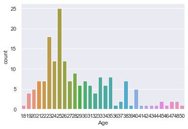

```python
sns.countplot(data=cardiodata, x='Age'); # to plot a graph on number of customers based on age.
```

Observation: The Age ranges from 18 to 50, most of the customers are Ages 23 or 25

### 2.b Grouping the Age to groups for a better plot using binning

```python
cardiodata['Age-QCut']=pd.qcut(cardiodata.Age, q=5,labels=['17-23','23-25','25-29','29-34','34-50'])
# Using Quantile Cut the year column to 5 equal quantiles by specifiying q=5
# Also adding the new column Age-Qcut to the dataframe
cardiodata.head(5)
```

|  | Product | Age | Gender | Education | MaritalStatus | Usage | Fitness | Income | Miles | Age-QCut |
| --- | --- | --- | --- | --- | --- | --- | --- | --- | --- | --- |
| 0 | TM195 | 18 | Male | 14 | Single | 3 | 4 | 29562 | 112 | 17-23 |
| 1 | TM195 | 19 | Male | 15 | Single | 2 | 3 | 31836 | 75 | 17-23 |
| 2 | TM195 | 19 | Female | 14 | Partnered | 4 | 3 | 30699 | 66 | 17-23 |
| 3 | TM195 | 19 | Male | 12 | Single | 3 | 3 | 32973 | 85 | 17-23 |
| 4 | TM195 | 20 | Male | 13 | Partnered | 4 | 2 | 35247 | 47 | 17-23 |

Observation: A new grouping column named Age-Qcut is added for better results in grouping of customer age.

### 2.c Customer Counts on Age Groups

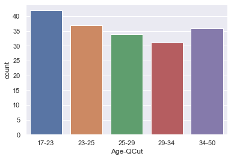

```python
sns.countplot(data=cardiodata, x='Age-QCut'); #Plotting the Age-Group of Customers on counts
```

Observation: Majority of Customers are in the Age group (17-23) , Customers are lowest in the Age Group 29-34

### 2.d Genderwise breakdown of Age Group of Customers

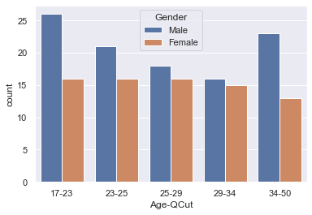

```python
sns.countplot(data=cardiodata, x='Age-QCut', hue='Gender'); # Genderwise breakdown of Age of Customers
```

Observation: In all the age groups , female are lower compared to male customers

### 2.e Popularity of the different models of TreadMills

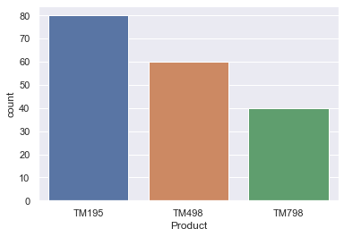

```python
sns.countplot(data=cardiodata,x='Product'); # Counting the number of Products in the dataset
```

Observation: TM195 is the most popular TreadMill model, followed by TM498 and TM798

### 2.f Plotting Years of Education of Customers

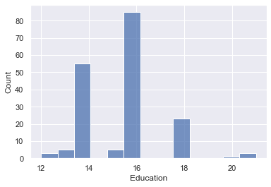

```python
sns.histplot(cardiodata.Education);
```

Observation : Majority of Customers have 16 years of Education, the next group is 14 years

### 2.g Income Level of Customers

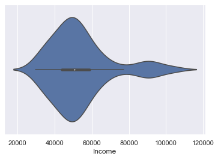

```python
sns.violinplot(cardiodata.Income); # Plots a violin plot on the income level of customers
```

### 2.h Number of times a customer wants to use the treadmill everyweek

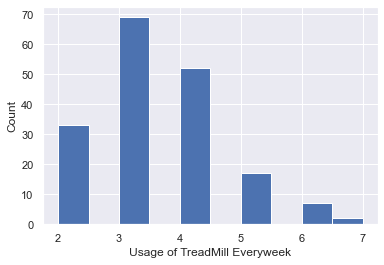

```python
plt.hist(cardiodata['Usage']);
plt.xlabel('Usage of TreadMill Everyweek')
plt.ylabel('Count')
plt.show()
```

Observation: Majority of customers use treadmills 3 times a week.

### 2.i Fitness Level of Customers

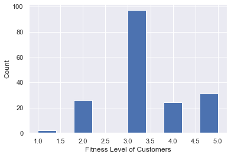

```python
plt.hist(cardiodata['Fitness'])
plt.xlabel('Fitness Level of Customers') # x-axis label
plt.ylabel('Count') # y-axis label
plt.show()
```

Observation: Majority of Customers are in the mid level of fitness close to 3

### 2.j Miles a customer expect to run

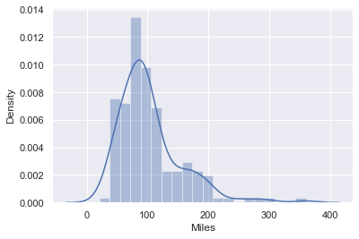

```python
sns.distplot(cardiodata.Miles); # Plots a distribution plot on the number of miles run by a customer
```

Observation: Majority of customers , run around 100 miles , but there are few who runs close to 400 miles, so Mostly a right heavy tail

### 2.k Plotting Marital Status of Customers

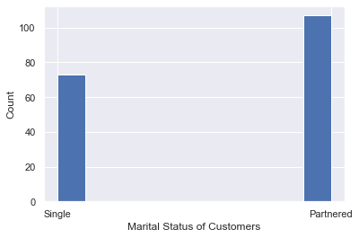

```python
plt.hist(cardiodata['MaritalStatus']);
plt.xlabel('Marital Status of Customers')
plt.ylabel('Count')
plt.show()
```

# 3 Multivariate Analysis

### 3.a Quick overview of existence of correlation between numeric columns

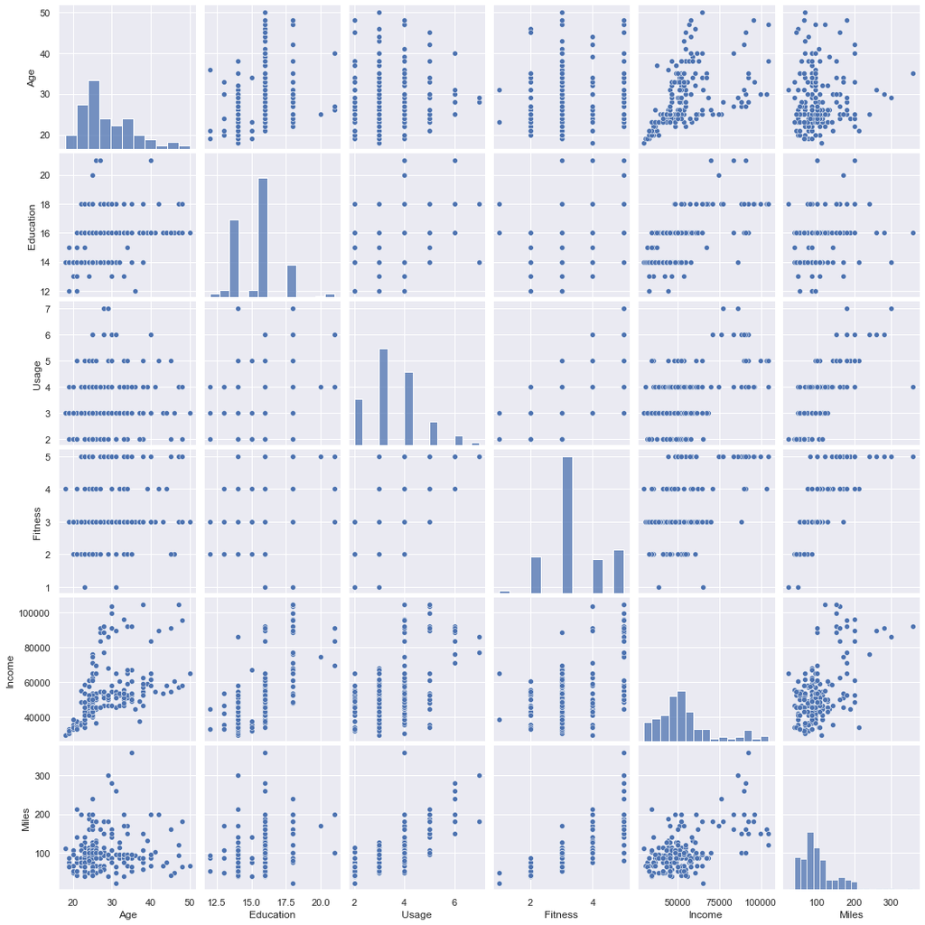

```python
sns.pairplot(cardiodata); #pairplot plot scatter diagrams for all numerical columns in the dataset.
```

### 3.b Identify the correlation value using corr() and heatmap functions

```python
cor=cardiodata.corr()
cor
```

|  | Age | Education | Usage | Fitness | Income | Miles |
| --- | --- | --- | --- | --- | --- | --- |
| Age | 1.000000 | 0.280496 | 0.015064 | 0.061105 | 0.513414 | 0.036618 |
| Education | 0.280496 | 1.000000 | 0.395155 | 0.410581 | 0.625827 | 0.307284 |
| Usage | 0.015064 | 0.395155 | 1.000000 | 0.668606 | 0.519537 | 0.759130 |
| Fitness | 0.061105 | 0.410581 | 0.668606 | 1.000000 | 0.535005 | 0.785702 |
| Income | 0.513414 | 0.625827 | 0.519537 | 0.535005 | 1.000000 | 0.543473 |
| Miles | 0.036618 | 0.307284 | 0.759130 | 0.785702 | 0.543473 | 1.000000 |

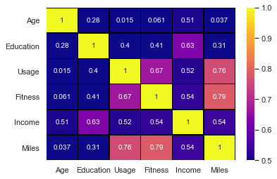

```python
sns.heatmap(cor,annot=True,cmap='plasma',vmin=0.5,vmax=1, linecolor ='black', linewidth=0.5)
```

Observation: There is a high correlation between

Usage & Fitness,

Miles & Usage,

Miles & Fitness and

Education & Income (as heatmap values are above 0.5)

### 3.c Boxplot graph showing 3 Products and their usage across Customer Age

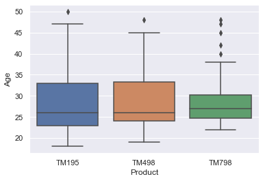

```python
sns.boxplot(data=cardiodata, x= 'Product', y='Age'); # Boxplot graph with Product on x axis and Age on y axis
```

Observation: This graph shows the 3 quartile values of distribution with extreme values. 1) The product TM195 and TM498 has each 1 observation of Age, outside the whisker as outlier , TM798 has few additional values outside the whiskers.

2) TM195 is most popular among wider range of age groups

### 3.d Relationship between Usage and Fitness

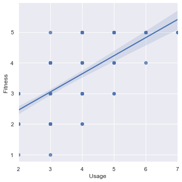

```python
sns.lmplot(x="Usage", y="Fitness", data=cardiodata);
```

Observation: Linear relationship between Usage and Fitness ; as Usage increases Fitness increases

### 3.e Relationship between Miles and Usage

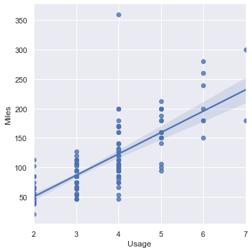

```python
sns.lmplot(x="Usage", y="Miles", data=cardiodata);
```

Observation: Linear relationship between Usage and Miles ; as Usage increases Miles Run increases

### 3.f Relationship between Education and Income

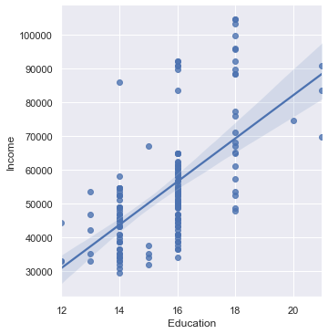

```python
sns.lmplot(x="Education", y="Income", data=cardiodata);
```

Observation: Linear relationship between Education and Income; as higher the number of years of Education, income level is also higher

### 3.g Relationship between Products and its usage, across Genders in all customers

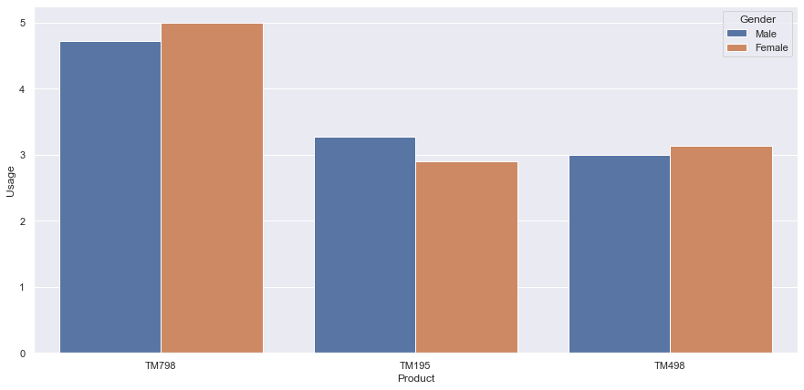

```python
plt.figure(figsize=(15, 7)) # To resize the plot
sns.barplot(data = cardiodata, x = "Product", y = "Usage", hue='Gender',ci=None,
            order=cardiodata.groupby('Product').Usage.mean().sort_values(ascending = False).index)
plt.xticks(rotation=0) # To rotate the x axis lables
plt.show()
```

Observation: Comparing the 3 products and their usage, across the Gender, we can see that Female Customers have a higher usage of Products TM798 and TM498

### 3.h Relationship between Product and Income level of Customers , across Genders

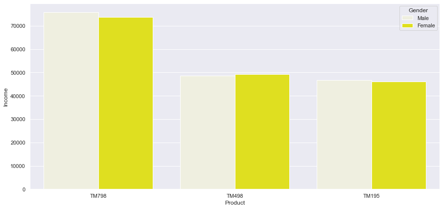

```python
plt.figure(figsize=(15, 7)) # To resize the plot
sns.barplot(data = cardiodata, x = "Product", y = "Income", hue='Gender',ci=None, color='yellow',
            order=cardiodata.groupby('Product').Income.mean().sort_values(ascending = False).index)
plt.xticks(rotation=0) # To rotate the x axis lables
plt.show()
```

Observation: Product TM798 is popular among the higher income group of customers, TM498 and TM195 are popular among income levels upto 50000; There is no noticeable preference for Male Vs Female for the choice of a product.

### 3.i How different age groups fare on the usage, across genders

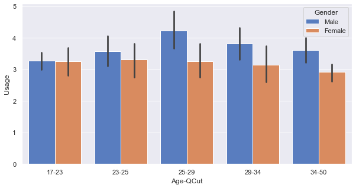

```python
plt.figure(figsize=(10,5))  # setting the figure size
ax = sns.barplot(x='Age-QCut', y='Usage', hue='Gender', data=cardiodata, palette='muted')  # barplot
```

Observation: Males in the Age group of 25-29 has the highest usage, the rest age groups are relatively same level of usages.In all age groups except 17-23, Males has higher usage of treadmills compared to Females

### 3.j Relationship of marital status of customers and products

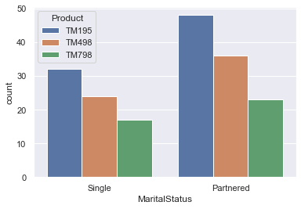

```python
sns.countplot(data=cardiodata,x='MaritalStatus', hue='Product'); # Counting the number of Customer's split into their Marital Status vs various Products
```

Observation: Customers with Marital Status='Partnered' are more compared to Single status. In both statuses, the popularity of Products is in the same levels. (TM195 being the most popular)

### 3.k Usage of Products vs Age of Customers and Across Genders

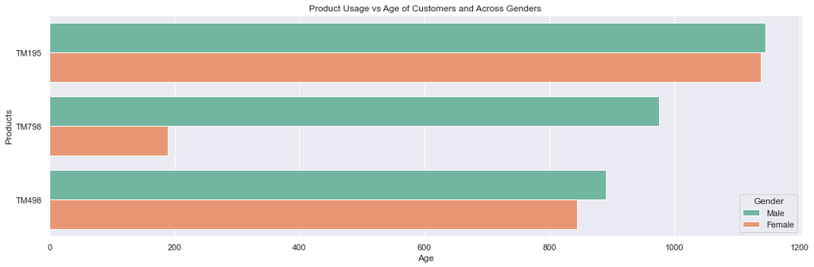

```python
cust_summary = cardiodata['Age'].groupby([cardiodata['Product'],cardiodata['Gender']]).sum()  # usage of Products by Age and sex
cust_summary = cust_summary.reset_index().sort_values(by='Age',ascending=False) # sort in descending order
products = cust_summary.head(10)  # getting the top ten records

fig = plt.figure(figsize=(15,5))
plt.title('Product Usage vs Age of Customers and Across Genders')

sns.barplot(y='Product',x='Age',hue='Gender',data=products,palette='Set2');

plt.ylabel('Products')
plt.tight_layout()
```

Observation: TM498 and TM798 has lowest usage in both age groups

### 3.l Average number of Customer Ages aross each Product, for a given gender with confidence intervals

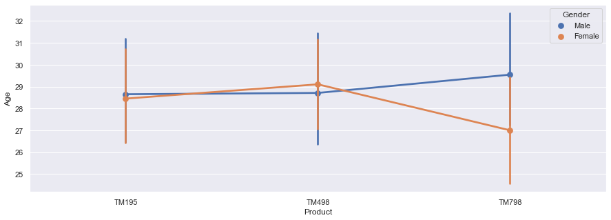

```python
plt.figure(figsize=(15,5))
sns.pointplot(x="Product", y="Age", hue='Gender', data=cardiodata) #PointPlot to calculate Averages of Age, across Products
plt.show()
```

Observation: The graph tells the average ages of customers , using 3 products and their confidence interval

Average Age of Female Customers are less for Product TM798

### 3.m Relationship between Products and Usage

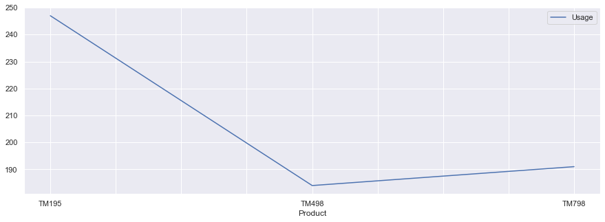

```python
cardiodata[['Usage','Product']].groupby(['Product']).sum().plot(figsize=(15,5)) #Plotting Product and Usage
plt.show()
```

Observation: Customers who has TM498 , reports the lowest usage, followed by TM798

### 3.n Relationship of Fitness and Age of Customers , across Marital Status and Gender

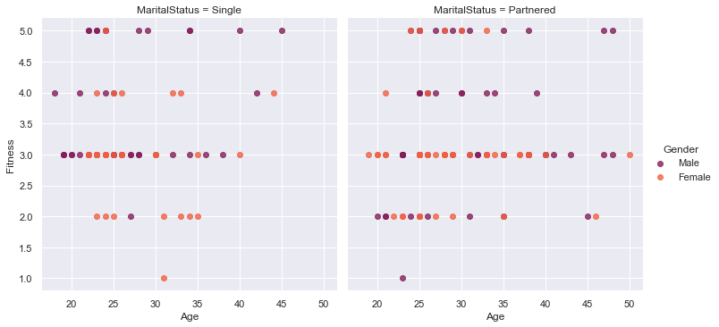

```python
sns.lmplot(x='Age',y='Fitness',data=cardiodata,fit_reg=False,hue='Gender',col='MaritalStatus',palette='rocket')
plt.show()
```

Observation: There is no visible linear relationship between Age and Fitness in both Single and Partnered Customers

Majority of Customers , irrespective of their Gender or Marital Status are in Fitness level of 3

There are a few outliers of Partnered Customers near Age 50 , in high fitness level of 5

# 4 Insights for Business

This Exploratory Data Analysis is on a dataset of 180 customers, using 3 Treadmill Products TM195,TM798 and TM498 and their profiles (based on Age, Gender, Education and Fitness Levels)

a) The Customer Ages ranges from 18 to 50, most of the customers are in age group 17-23 (Reference 2.a and 2.c)

b) Male Customers are majority in all age groups. (Reference 2.d)

c) Most customers have 16 years of education and income ranges of 40000 to 60000 (Reference 2.f and 2.g)

d) Majority of Customers use Treadmills 3 times a week, and have a fitness of 3/5 (Reference 2.i and 2.h)

g) Higher Income customers have TM798 (Reference 3.h)

Recommendations:

a) Increase the sales of Treadmills to higher age groups, specifically 25-35 and 35-higher.

b) TM798 seems to be the most expensive Treadmill, as it is mostly used by higher income customers. A lower price may attract more customers.

c) To add more female customers, add more friendly features and increase the visibility of these products to this customer base.

d) Partnered Customers are a majority of customers, market the product line as a family friendly product.

e) Increase the awareness of fitness levels by adding features to monitor/tracking the usage and fitness levels.